# STAT/MATH 495: Problem Set 09

Meredith Manley

2017-11-07

# Collaboration

Please indicate who you collaborated with on this assignment:

# Question 1: Run k-means

```r
observations_1 <- read_csv("data/observations_1.csv")
observations_2 <- read_csv("data/observations_2.csv")
```

### observation_1

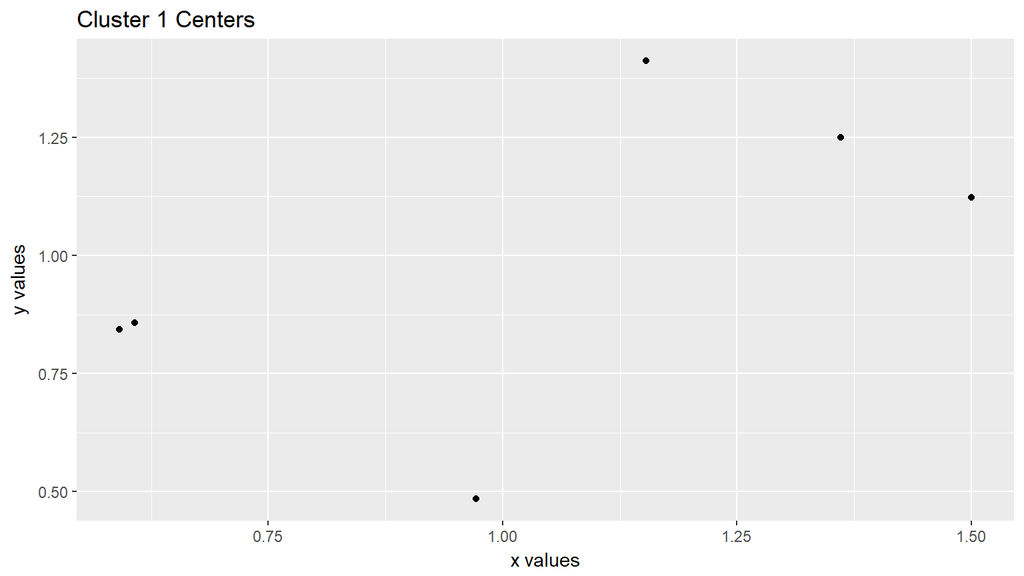

```r
# Empty data frame to store center coordinates
obs1_centers <- as.data.frame(c())

# For-loop to generate 10 center coordinates
for (i in 1:10) {

  # Set observations to be one of two datasets
  observations <- observations_1

  # Fit model for k=2
  k <- 2
  k_means_results <- kmeans(observations, centers=k)
  clusters <- k_means_results$cluster
  cluster_centers <- k_means_results$centers

  # Build vector for cluster 1 and cluster 2 centers
  cluster_centers_vect <- as.vector(cluster_centers)
  cluster_centers_vect[1] -> obs1_centers[i,1]
  cluster_centers_vect[3] -> obs1_centers[i,2]
  cluster_centers_vect[2] -> obs1_centers[i,3]
  cluster_centers_vect[4] -> obs1_centers[i,4]

  # Add cluster results to observations. Note we convert to factor since cluster
  # ID's should be treated as categorical
  observations$cluster <- as.factor(clusters)

  # Add cluster ID's to cluster_centers
  cluster_centers <- cluster_centers %>%
    as_tibble() %>%
    mutate(cluster=as.factor(1:k))

  # Plot displaying location of centers respective to 100 observations
  ggplot(NULL, aes(x=x1, y=x2, col=cluster)) +
    geom_point(data=observations) +
    geom_point(data=cluster_centers, size=5)
}

# Name variables for center data frame
colnames(obs1_centers)[1] <- "x1"
colnames(obs1_centers)[2] <- "y1"
colnames(obs1_centers)[3] <- "x2"
colnames(obs1_centers)[4] <- "y2"

# Plot of cluster 1 centers
ggplot(NULL, aes(x=x1, y=y1)) +
  geom_point(data=obs1_centers) +
  labs(x="x values", y="y values", title = "Cluster 1 Centers")
```

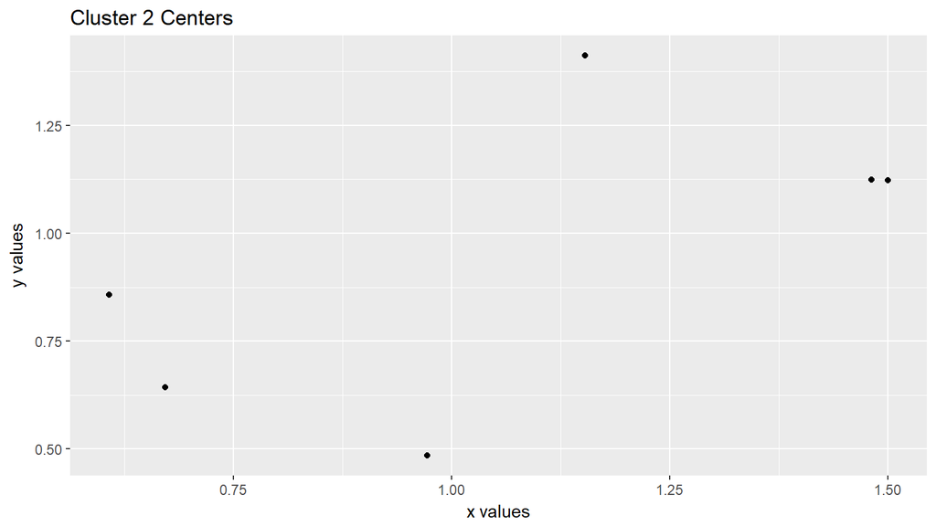

```r
# Plot of cluster 2 centers
ggplot(NULL, aes(x=x2, y=y2)) +
  geom_point(data=obs1_centers) +
  labs(x="x values", y="y values", title = "Cluster 2 Centers")
```

### observation_2

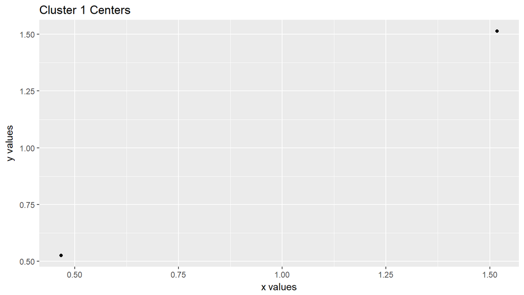

```r
# Empty data frame to store center coordinates
obs2_centers <- as.data.frame(c())

# For-loop to generate 10 center coordinates
for (i in 1:10) {

  # Set observations to be one of two datasets
  observations <- observations_2

  # Fit model for k=2
  k <- 2
  k_means_results <- kmeans(observations, centers=k)
  clusters <- k_means_results$cluster
  cluster_centers <- k_means_results$centers

  # Build vector for cluster 1 and cluster 2 centers
  cluster_centers_vect <- as.vector(cluster_centers)
  cluster_centers_vect[1] -> obs2_centers[i,1]
  cluster_centers_vect[3] -> obs2_centers[i,2]
  cluster_centers_vect[2] -> obs2_centers[i,3]
  cluster_centers_vect[4] -> obs2_centers[i,4]

  # Add cluster results to observations. Note we convert to factor since cluster
  # ID's should be treated as categorical
  observations$cluster <- as.factor(clusters)

  # Add cluster ID's to cluster_centers
  cluster_centers <- cluster_centers %>%
    as_tibble() %>%
    mutate(cluster=as.factor(1:k))

  # Plot displaying location of centers respective to 100 observations
  ggplot(NULL, aes(x=x1, y=x2, col=cluster)) +
    geom_point(data=observations) +
    geom_point(data=cluster_centers, size=5)
}

# Name variables for center data frame
colnames(obs2_centers)[1] <- "x1"
colnames(obs2_centers)[2] <- "y1"
colnames(obs2_centers)[3] <- "x2"
colnames(obs2_centers)[4] <- "y2"

# Plot of cluster 1 centers
ggplot(NULL, aes(x=x1, y=y1)) +
  geom_point(data=obs2_centers) +
  labs(x="x values", y="y values", title = "Cluster 1 Centers")
```

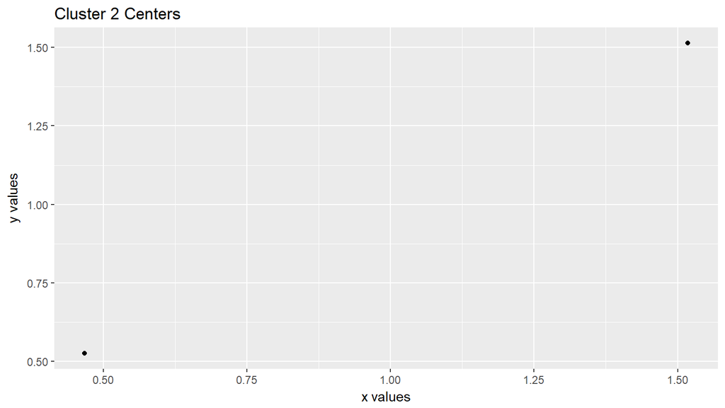

```r
# PLot of cluster 2 centers
ggplot(NULL, aes(x=x2, y=y2)) +
  geom_point(data=obs2_centers) +
  labs(x="x values", y="y values", title = "Cluster 2 Centers")
```

**Questions**:

1. Run KMC 10 times on `observations_1` and comment on the consistency of the results.
2. Speculate on the root cause of any consistency or inconsistency in the results.
3. Run KMC 10 times on `observations_2` and comment on the consistentcy of the results.
4. Speculate on the root cause of any consistency or inconsistency in the results.

**Answers**:

1. After having run KMC several times on `observations_1` I observed that the center point of the clusters and the clusters themselves were relatively incosistent.
2. The center coordinate pairs seem to vary because the data is scattered relatively evenly across the plot and thus results in different possible centers for different possible clusters. The data does not have a natural split or have distinct groupings of observations thus resulting in the variation in cluster center placement and clusters.
3. After having run KMC several times on `obersvations_2` I observed that the center point of the clusters and the clusters were fairly consistent and were generally in the same place with each run.
4. The center coordinate pairs do not vary considerably between runs because the data is already essentially split into two groups, thus makeing it easy to determine where the center for each cluster should be and therefore being consistent between runs. Because the data appears to already be divided into two different groups then the calculation of center points will be consistent between runs.

# Bonus question: Code your own

Read ISLR page 388 Algorithm 10.1 and implement k-means clustering from scratch. Don’t worry about doing it for general $k$; keep it simple and do it for $k=2$ specifically. Apply it to `observations_2` from above.

```r
# Hint:
library(proxy)
A <- data_frame(
  x1 = c(0, 0.5, 0.75, 1),
  x2 = c(0, 0.5, 0.75, 1)
)
B <- data_frame(
  x1 = c(1, 0),
  x2 = c(1, 0)
)
distance_matrix <- proxy::dist(x=A, y=B)
distance_matrix
```

```
##      [,1]      [,2]
## [1,] 1.4142136 0.0000000
## [2,] 0.7071068 0.7071068
## [3,] 0.3535534 1.0606602
## [4,] 0.0000000 1.4142136
```

```r
apply(distance_matrix, 1, which.min)
```

```
## [1] 2 1 1 1
```